# Práctico 1 Introducción a R

Derek Corcoran  
"06/03, 2018"

### R y RStudio

- Programa escrito por estadísticos
- RStudio (IDE para R, Python, C++, etc) facilita su uso
- extensión en base a [paquetes](https://cran.r-project.org/web/packages/available_packages_by_name.html)
  - Los mejores publicados en [Journal of Statistical Software](https://www.jstatsoft.org/index), Methods in Ecology and Evolution u otro journal
  - Stackoverflow, siempre ver la reputación de los autores
- Aprendiendo R desde R con [Swirl](http://swirlstats.com/students.html)

### Estructura de datos

- Vector: Un conjunto lineal de datos (secuencia génica, serie de tiempo)
- Matrix: Una tabla con solo números
- Data Frame: Una tabla donde cada columna tiene un tipo de datos (estándar dorado)
- List: Aqui podemos meter lo que queramos

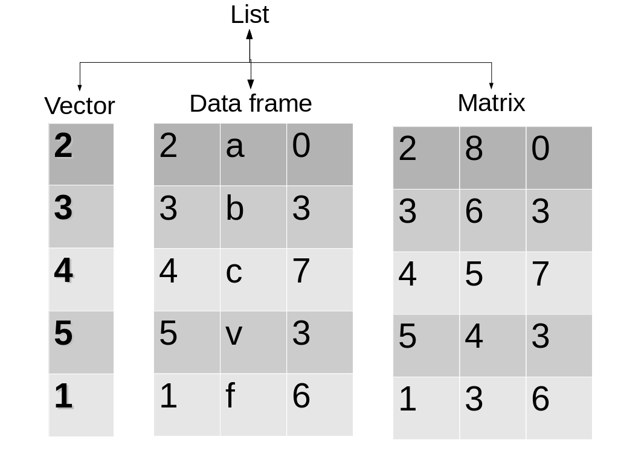

### Vector

- Secuencia lineal de datos
- Pueden ser de muchos tipos (numéricos, de carácteres, lógicos, etc.)
- Ejemplo data(uspop)
- para crear uno c(1,4,6,7,8)
- para subsetear un vector se pone el índice entre []
- uspop[4], uspop[2:10], uspop[c(3,5,8)]

[figure not shown]

### Data Frame

- Una tabla, cada columna un tipo de datos (Numérico, lógico, etc)
- Cada columna un vector
- Ejemplo data(iris)
- Para subsetear data.frame[filas,columnas]
- Ejemplos iris[,3], iris[,“Petal.Length”], iris[2:5,c(1,5)], iris$Petal.Length

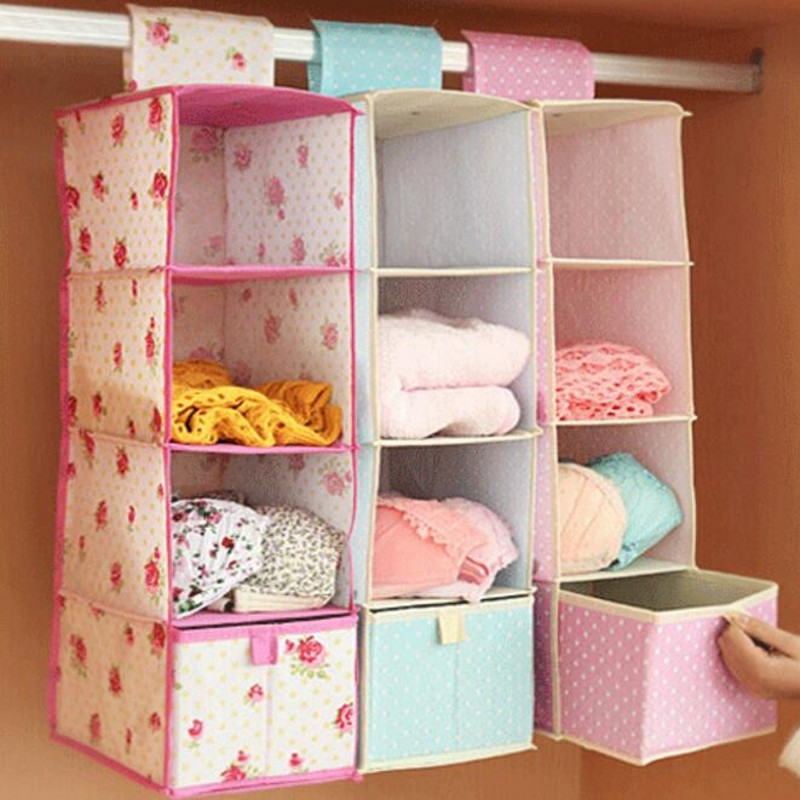

### Tidy Data

- Cada columna una variable
- Cada fila una observación

### untidy data

[figure not shown]

### untidy data

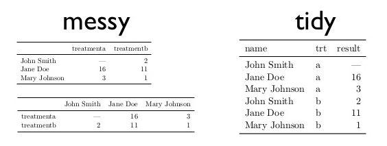

### tidyverse

Paquete con pocas funciones [muy poderosas](https://www.rstudio.com/wp-content/uploads/2015/02/data-wrangling-cheatsheet.pdf), trabajaremos con

- *summarize*
- *group_by*
- *filter*
- *%>%* pipeline

### summarize y group_by

- *summarize* resume una variable
- *Group_by* reune observaciones según una variable
- Usadas en conjunto muy poderosas

```r
library(dplyr)
library(knitr)
MEAN <- summarize(iris, MEAN.PETAL = mean(Petal.Length))
kable(MEAN)
```

| MEAN.PETAL |
| --- |
| 3.758 |

### summarize y group_by (continuado)

```r
library(dplyr)
library(knitr)
MEAN <- group_by(iris, Species)
MEAN <- summarize(MEAN, MEAN.PETAL = mean(Petal.Length))
kable(MEAN)
```

| Species | MEAN.PETAL |
| --- | --- |
| setosa | 1.462 |
| versicolor | 4.260 |
| virginica | 5.552 |

### Pipeline (%>%)

- Ahorra líneas, se parte con un data.frame
- Se agregan funciones de dplyr hasta llegar al resultado deseado

```r
library(dplyr)
library(knitr)
MEAN <- iris %>% group_by(Species) %>% summarize(MEAN.PETAL = mean(Petal.Length))
kable(MEAN)
```

| Species | MEAN.PETAL |
| --- | --- |
| setosa | 1.462 |
| versicolor | 4.260 |
| virginica | 5.552 |

### Pipeline (%>%) otro ejemplo

```r
library(dplyr)
library(knitr)
MEAN <- iris %>% group_by(Species) %>% summarize_all(mean)
kable(MEAN)
```

| Species | Sepal.Length | Sepal.Width | Petal.Length | Petal.Width |
| --- | --- | --- | --- | --- |
| setosa | 5.006 | 3.428 | 1.462 | 0.246 |
| versicolor | 5.936 | 2.770 | 4.260 | 1.326 |
| virginica | 6.588 | 2.974 | 5.552 | 2.026 |

### Filter

- Selecciona según una o más variables

| simbolo | significado | simbolo_cont | significado_cont |
| --- | --- | --- | --- |
| < | Menor que | != | distinto a |
| > | Mayor que | %in% | dentro del grupo |
| == | Igual a | is.na | es NA |
| >= | mayor o igual a | !is.na | no es NA |
| <= | menor o igual a | \| & | o, y |

### Ejemplos de filter agregando a lo anterior

```r
library(dplyr)
data("iris")
DF <- iris %>% filter(Species != "versicolor") %>% group_by(Species) %>% summarise_all(funs(mean, sd))
kable(DF)
```

| Species | Sepal.Length_mean | Sepal.Width_mean | Petal.Length_mean | Petal.Width_mean | Sepal.Length_sd | Sepal.Width_sd | Petal.Length_sd | Petal.Width_sd |
| --- | --- | --- | --- | --- | --- | --- | --- | --- |
| setosa | 5.006 | 3.428 | 1.462 | 0.246 | 0.3524897 | 0.3790644 | 0.1736640 | 0.1053856 |
| virginica | 6.588 | 2.974 | 5.552 | 2.026 | 0.6358796 | 0.3224966 | 0.5518947 | 0.2746501 |

### Select

- Selecciona columnas dentro de un data.frame

```r
library(dplyr)
library(knitr)
data(nasa)
Nasa2 <- as.data.frame(nasa)
Temp <- Nasa2 %>% filter(year != 1995) %>% group_by(year) %>% select(contains("temp")) %>% summarize_all(mean)
```

```r
kable(Temp)
```

| year | surftemp | temperature |
| --- | --- | --- |
| 1996 | 295.8562 | 297.1005 |
| 1997 | 296.7291 | 297.9566 |
| 1998 | 297.1221 | 298.7028 |
| 1999 | 295.6850 | 298.1364 |
| 2000 | 295.7263 | 298.3358 |

### Ejercicios

- Usando la base de datos *storm* del paquete *tidyverse*, calcula la velocidad promedio y diámetro promedio (hu_diameter) de las tormentas declaradas huracanes por año
  - solución:
  - storms %>% filter(status == “hurricane”) %>% select(year, wind, hu_diameter) %>% group_by(year) %>% summarize_all(mean)

### Visualización de datos (ggplot2)

- Paquete de visualización de datos de tidy data.
- ggplot(data.frame, aes(nombres de columna)).
- + geom_algo(argumentos, aes(columnas)).
- + theme_algo() estilo.
- Personalización de ejes y leyendas.
- Dos [links](http://zevross.com/blog/2014/08/04/beautiful-plotting-in-r-a-ggplot2-cheatsheet-3/) para aprender [mas](https://www.rstudio.com/wp-content/uploads/2015/03/ggplot2-cheatsheet.pdf).

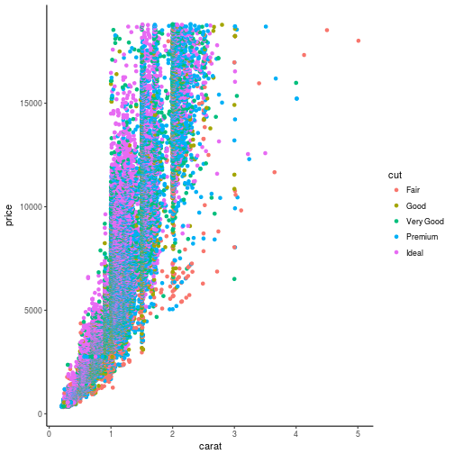

```r
library(ggplot2)
data("diamonds")
ggplot(diamonds, aes(x = carat, y=price)) + geom_point(aes(color = cut)) + theme_classic()
```

### Argumentos para geoms

- **color**: color de líneas o puntos
- **alpha**: transparencia, de 0 (transparente) a 1 (sólido)
- **size**: tamaño de puntos
- **pch**: típo de punto
- **fill**: color dentro de un área (barras, intervalos)

### color

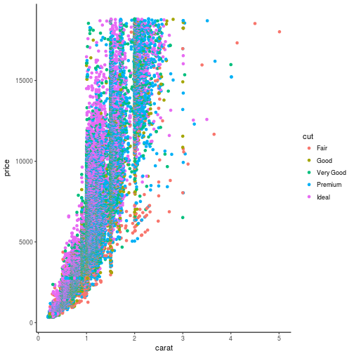

```r
library(ggplot2)
data("diamonds")
ggplot(diamonds, aes(x = carat, y=price)) + geom_point(aes(color = cut)) + theme_classic()
```

### alpha

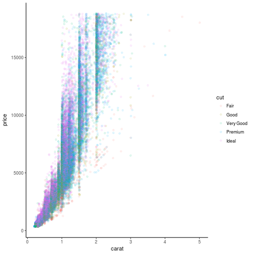

```r
library(ggplot2)
data("diamonds")
ggplot(diamonds, aes(x = carat, y=price)) + geom_point(aes(color = cut), alpha = 0.1) + theme_classic()
```

### size

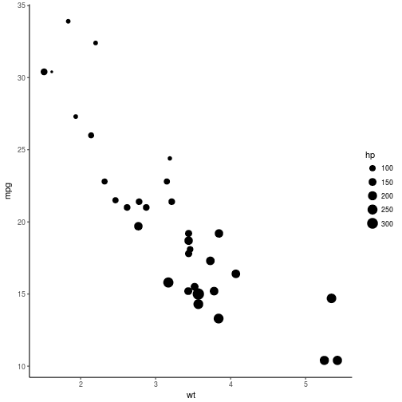

```r
library(ggplot2)
data("mtcars")
ggplot(mtcars, aes(x = wt, y=mpg)) + geom_point(aes(size = hp)) + theme_classic()
```

### shape

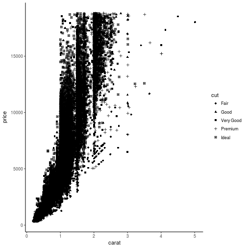

```r
library(ggplot2)
data("diamonds")
ggplot(diamonds, aes(x = carat, y=price)) + geom_point(aes(shape = cut)) + theme_classic()
```

### fill

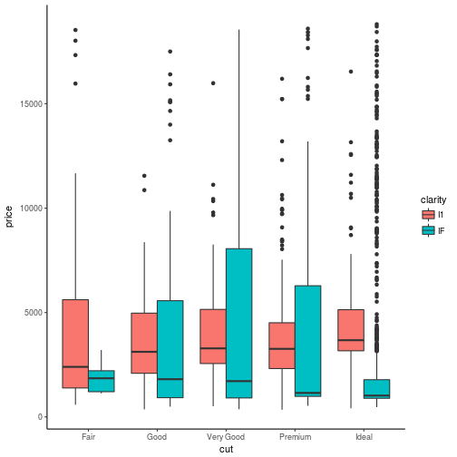

```r
library(dplyr)
d2 <- diamonds %>% filter(clarity == "I1" | clarity == "IF")
ggplot(d2, aes(x = cut, y=price)) + geom_boxplot(aes(fill = clarity)) + theme_classic()
```

### Una variable categórica una continua

- geom_boxplot
- geom_jitter
- geom_violin
- geom_bar

### geom_jitter

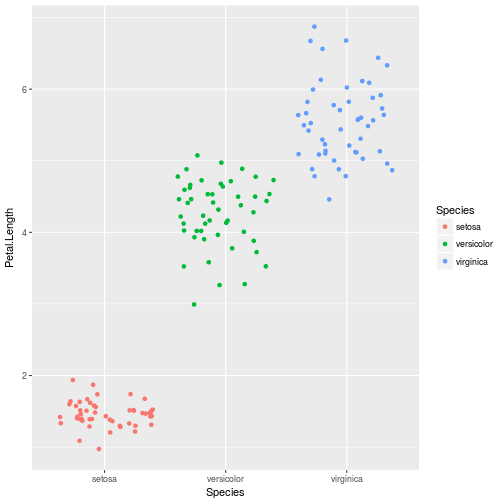

```r
data("iris")
ggplot(iris, aes(x = Species, y = Petal.Length)) + geom_jitter(aes(color = Species))
```

### geom_violin

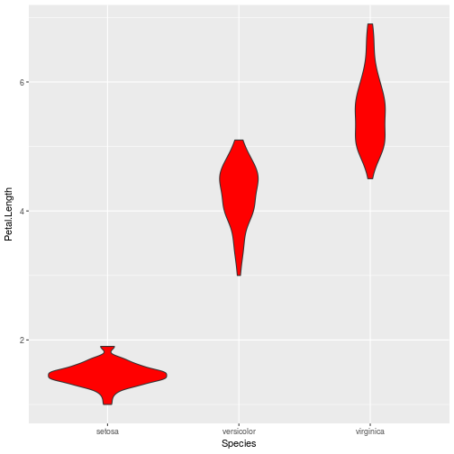

```r
data("iris")
ggplot(iris, aes(x = Species, y = Petal.Length)) + geom_violin(fill = "red")
```

### Se pueden combinar

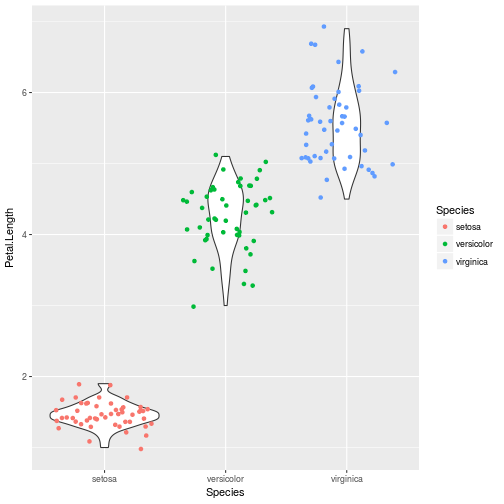

```r
data("iris")
ggplot(iris, aes(x = Species, y = Petal.Length)) + geom_violin() + geom_jitter(aes(color = Species))
```

### Pero el orden importa

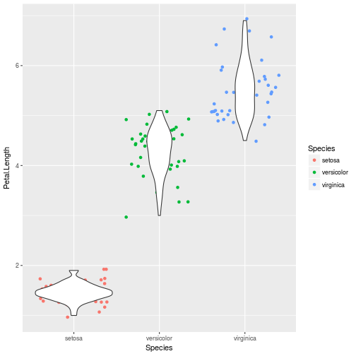

```r
data("iris")
ggplot(iris, aes(x = Species, y = Petal.Length)) + geom_jitter(aes(color = Species)) + geom_violin()
```